# Admixture graph, gene flow, and selection analyses

Running treemix:

```bash
for m in {0..5}
   do
   for k in 1 10 100
      do
      treemix -i unadmixed.frq.trm.gz  -m $m -o w3/unadmixed.w3.${k}.${m} -root W3
      done
done
```

For plotting treemix results (the treemix.r script is from here: https://github.com/MikkelSchubert/paleomix/blob/master/paleomix/resources/rscripts/zonkey/treemix.r):

```r
for (m in 0:5){
       png(paste("w3/unadmixed.w3.1.",m,".png",sep=""), width = 1280, height = 1280, res = 300)
        par(mar = c(2.5,2.5,2.5,2.5))
       plot_tree(paste("no_root/unadmixed.w3.1.",m,sep=""))
       dev.off()
        }
```

For exploring the appropriate number of migration edges:

```
No output file will be saved. To save an output file, run with 'pdf = "file.pdf"'

Plotting the treemix results using various linear models.

No plot file has been saved.

Finished plotting.  All results are saved to the current directory as requested.
```

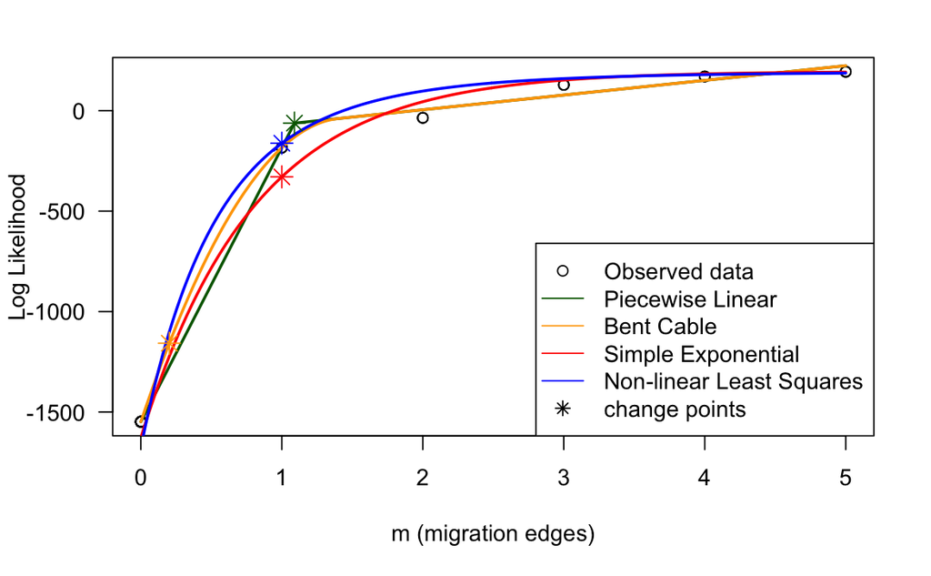

```r
OptM::plot_optM(w3_optm,method="linear")
```

While the tool recommends a change point (indicating the appropriate number of migration edges) based on a default threshold, we selected the three-migration model based on when the model likelihood appears to plateau.

Selection analysis using GRoSS

Convert file to GRoSS format using GLACTOOLS (4pops_to_keep.txt contains the IDs for individuals from C1, C2, C3, and W1 (submitted as a job on an HPC):

```bash
plink --bfile foxtail_het_maf0.01 --allow-extra-chr  --keep 4pops_to_keep.txt

glactools vcfm2acf --onlyGT --fai Yugu1_nine.fa.fai 4pop.vcf.gz  | glactools meld -f ../smcpp/meta-pop.txt  -  |\
glactools acf2gross --noroot - > 4pop.gross
```

Write admixture graph/tree topology in dot format:

```bash
cat treeGross.dot
```

```
digraph G {
R -> W1 [ ] ;
R -> ANC1 [ ] ;
ANC1 -> C3 [ ] ;
ANC1 -> ANC2 [ ] ;
ANC2 -> C1 [ ] ;
ANC2 -> C2 [ ] ;
}
```

Run GRoSS (submitted as a job on an HPC):

```bash
Rscript GRoSS.R -e 4pop.gross -d treeGross.dot -o SNPstat_out.tsv
```

```r
library("tidyverse")
library("reshape2")
```

The following code is adapted from an analysis template provided on the method’s github (https://github.com/FerRacimo/GRoSS/blob/master/Plotting_and_Windowing.txt):

```r
table <- read.table("SNPstat_out.tsv",sep="",header=TRUE)



# merge across 10 SNP windows with 5 SNP steps

average <- c()
for(chr in seq(1,9)){
print(chr)
onechr <- table[which(table[,1]==chr),]
pvalpos <- which(mapply(grep,"Pval",colnames(onechr)) == 1)
chipos <-  which(colnames(onechr) %in% colnames(onechr)[-c(pvalpos)][-c(1,2,3)])
onechr <- as.data.frame(t(apply(onechr,1,function(row){row[pvalpos] <- -log10(row[pvalpos]); return(row)})))
winsize <- 10
winstep <- 5
startvec <- seq(1,dim(onechr)[1]-winsize+1,winstep)
endvec <- seq(winsize,dim(onechr)[1],winstep)
winlims <- cbind(startvec,endvec)


# AVERAGE CHI-SQUARED (10 SNPs)
averagetemp <- as.data.frame(t(apply(winlims,1,function(window){
block <- onechr[seq(window[1],window[2]),]
chisqstats <- block[,chipos]
avgstats <- apply(chisqstats,2,mean)
avgpval <- 1 - pchisq(avgstats,1)
return(c(chr,onechr[window[1],2],onechr[window[2],3],avgstats,avgpval))
})))
colnames(averagetemp) <- colnames(onechr)
average <- rbind(average,averagetemp)
}
```

Reshape the table and determine cutoff for peaks:

|  | Branches | Pvals | SNPID | CHR | START | END |
| --- | --- | --- | --- | --- | --- | --- |
| 1 | Pval_W1_R | 0.4346316 | 1 | 1 | 5757 | 45423 |
| 2 | Pval_W1_R | 0.6843969 | 2 | 1 | 45383 | 45622 |
| 3 | Pval_W1_R | 0.8699371 | 3 | 1 | 45474 | 45829 |
| 4 | Pval_W1_R | 0.8753916 | 4 | 1 | 45633 | 45959 |
| 5 | Pval_W1_R | 0.7905625 | 5 | 1 | 45834 | 46129 |
| 6 | Pval_W1_R | 0.7841602 | 6 | 1 | 45975 | 46193 |

Getting -log10(pvalue) cutoff:

```r
(cutoff = quantile(c(-log10(melttab$Pvals)),
                       0.99999))
```

```
 99.999%
2.185763
```

Using this cutoff, I look for regions/windows under selection in the terminal branches leading up to C1, C2, and C3. Regions within 25 kb of each other collapsed together.

| Branch_leading_to | Chromosome | Start | End | Length |
| --- | --- | --- | --- | --- |
| c1 | 2 | 15581766 | 15594405 | 12639 |
| c1 | 2 | 15719709 | 15720134 | 425 |
| c1 | 2 | 16008523 | 16010089 | 1566 |
| c1 | 2 | 16044177 | 16104400 | 60223 |
| c1 | 2 | 16627654 | 16628682 | 1028 |
| c1 | 2 | 16737682 | 16739846 | 2164 |
| c1 | 2 | 16861594 | 16861972 | 378 |
| c1 | 2 | 16917372 | 16960187 | 42815 |
| c1 | 2 | 45582615 | 45590027 | 7412 |
| c1 | 3 | 22545881 | 22558826 | 12945 |

[output cut: 42 more lines]

```bash
head Regions_under_selection.csv
```

```
Branch leading to,Chromosome,Start,End,Length
c1,2,15581766,15594405,12639
c1,2,15719709,15720134,425
c1,2,16008523,16010089,1566
c1,2,16044177,16104400,60223
c1,2,16627654,16628682,1028
c1,2,16737682,16739846,2164
c1,2,16861594,16861972,378
c1,2,16917372,16960187,42815
c1,2,45582615,45590027,7412
```